# Documentation

Nishat Islam

2024-03-30

# Description

## The mars() function implements Multivariate Adaptive Regression Splines (MARS), a flexible method for regression modeling that can capture complex nonlinear relationships and interactions between variables.

# Usage

## mars(formula, data, control = mars.control())

# Arguments

## formula: A smbolic description of the model to be fitted, indicating the response variable and predictors.

## data: The dataset containing the variables mentioned in the formula.

## control: Optional. A list of parameters that control the fitting process. Default settings are applied if not specified.

# Details

## The mars() function fits a MARS model to the specified data. MARS is a non-parametric regression technique that builds models by fitting piecewise linear regressions. The function automatically identifies interaction terms and can model complex, high-dimensional datasets. The fitting process involves two main steps: a forward pass where terms are added to the model to reduce the residual sum of squares, and a backward pass where the least effective terms are pruned.

# Value

## Returns an object of class mars, which contains the fitted MARS model. This object includes components such as:

### coefficients: The model coefficients.

### terms: A list of model terms, including both basis functions and interactions.

### call: The matched call.

# References

## Friedman, J.H. (1991). Multivariate Adaptive Regression Splines. The Annals of Statistics, 19(1), 1-67.

# See Also

## anova.mars(): ANOVA for MARS Model Objects

# Examples

## test1 dataset of mtcars

```r
library(devtools)
load_all()
```

```
## ℹ Loading mars
```

```r
library(mars)
library(ISLR)
library(MASS)

# test1
data("mtcars")
mc1 = mars.control(Mmax = 10)
fit1 <- mars(mpg ~ wt + hp, data = mtcars, control=mc1)
predict1 = predict(fit1)
predict1
```

```
##  [1] 21.618559 20.545332 23.559535 19.114361 18.167395 18.083220 17.620259
##  [8] 25.155180 19.727106 18.167395 18.167395 15.515891 16.946861 16.736424
## [15] 10.549581  9.817261 10.149751 28.643476 33.479827 30.349253 22.270914
## [22] 17.830696 18.188439 16.483900 16.462857 29.758791 24.656285 26.277631
## [29] 19.303754 20.987249 17.620259 20.945162
```

```r
summary.mars(fit1)
```

```
## Summary of MARS Model
##
## Formula:
## mpg ~ wt + hp
##
## Number of Terms:  3
## Coefficients:
##         B0         B3         B6
## 26.2776315  0.1695886 -4.2087371
##
## Goodness-of-Fit Measures:
## R-Squared:  0.8509
## Adjusted R-Squared:  0.8349
##
## Residual Statistics:
## Residual Mean:  0
## Residual Standard Deviation:  2.3272
```

```
## $formula
## mpg ~ wt + hp
##
## $n_terms
## [1] 3
##
## $coefficients
##         B0         B3         B6
## 26.2776315  0.1695886 -4.2087371
##
## $r_squared
## [1] 0.8509046
##
## $adj_r_squared
## [1] 0.8349301
##
## $residual_mean
## [1] 6.289728e-17
##
## $residual_sd
## [1] 2.327178
```

```r
anova.mars(fit1)
```

```
## Intercept:
## * Variance explained by term: 0
## * Residual variance for term: 5.4158
## * Fitted value variance for term: 30.9083
##
## Term: B3
## * Variance explained by term: 4.7973
## * Residual variance for term: 1687.0907
## * Fitted value variance for term: 152634.814
##
## Term: B6
## * Variance explained by term: 16.9585
## * Residual variance for term: 20.9494
## * Fitted value variance for term: 125.1912
```

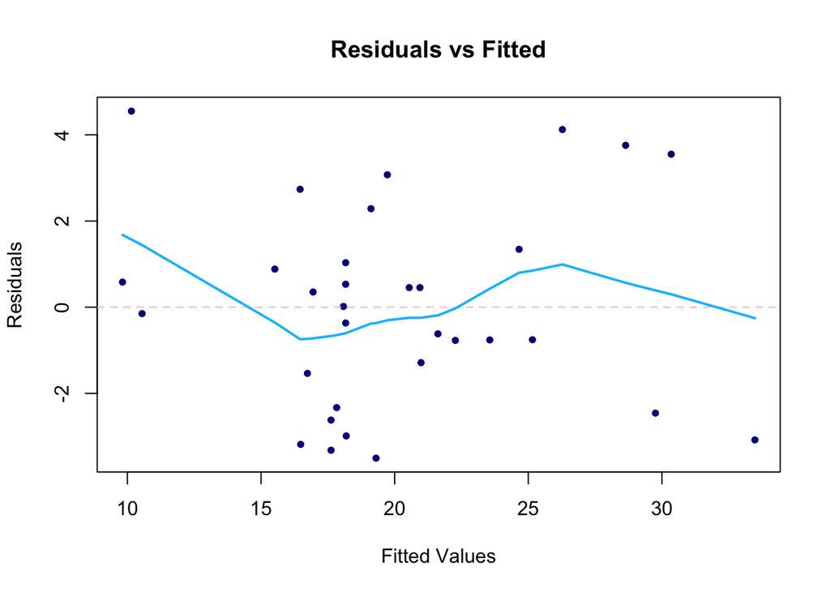

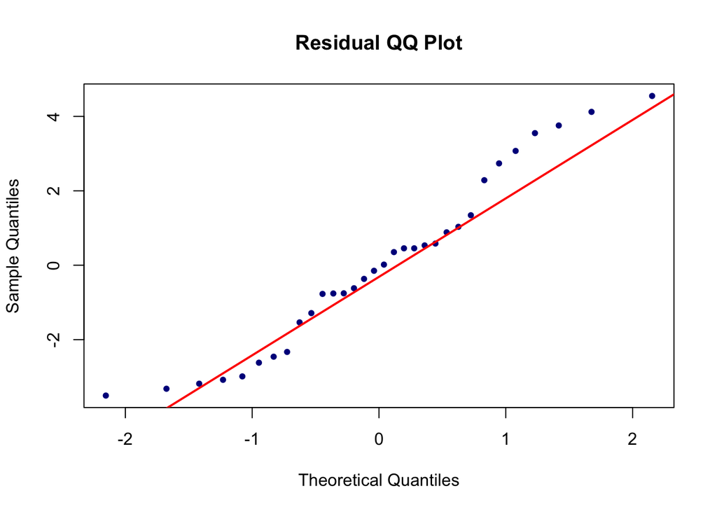

```r
plot.mars(fit1)
```

```r
print.mars(fit1)
```

```
## FUNCTION CALL:
##  mars(formula = mpg ~ wt + hp, data = mtcars, control = mc1)
## RESULT:
##  Coefficients:
##  26.2776314801465    B0
##  0.169588603990351   B3
##  -4.20873712239424   B6
```

## test2 dataset for Air Quality

```r
#test2
data("airquality")
# Clean the dataset to remove NA values for simplicity
airquality_clean <- na.omit(airquality)

mc_airquality = mars.control(Mmax = 10)
fit_airquality <- mars(Ozone ~ Solar.R + Wind + Temp, data = airquality_clean, control=mc_airquality)
predict_airquality = predict(fit_airquality)
predict_airquality
```

```
##   [1]  34.60324  24.79328  14.98332  14.98332  14.98332  14.98332  14.98332
##   [8]  14.98332  14.98332  14.98332  14.98332  14.98332  14.98332  14.98332
##  [15]  14.98332  14.98332  14.98332  14.98332  14.98332  14.98332  14.98332
##  [22]  40.09050  78.96813  38.78777  29.85903  77.75127  65.19768  42.06656
##  [29]  21.92339  14.98332  14.98332  14.98332  17.31857 110.65851  56.82862
##  [36]  40.09050  96.23255  48.45956  98.36794  94.56404  96.76675  67.41136
##  [43]  14.98332  33.78613  17.30806  67.88539  44.27503  82.29590  88.63491
##  [50]  55.77789  42.77821  61.01315  63.45201  23.09233  27.95721  76.04190
##  [57]  73.71739  65.31321  40.09050  49.98096  14.74691  40.74071 106.36024
##  [64]  77.75127  75.66318  53.38486  44.27503  28.76101  16.87989  54.70014
##  [71]  36.47617  27.53691  25.33038  23.35238  14.98332  30.62868 125.11016
##  [78]  65.05366  96.87192 103.09489 100.69812  82.85783  70.63472  88.96652
##  [85]  89.02552  86.76168  43.73603  27.48963  35.90597  27.22169  14.98332
##  [92]  14.98332  40.09050  19.16785  60.95723  14.98332  14.98332  55.33180
##  [99]  14.98332  15.00696  14.98332  49.86297  14.98332  14.98332  29.24698
## [106]  14.98332  14.98332  42.77821  14.98332  27.00244  14.98332
```

```r
summary.mars(fit_airquality)
```

```
## Summary of MARS Model
##
## Formula:
## Ozone ~ Solar.R + Wind + Temp
##
## Number of Terms:  5
## Coefficients:
##          B0          B2          B3          B6          B7
## 14.98332058  4.18452986 16.34993426 -1.15261394 -0.02101458
##
## Goodness-of-Fit Measures:
## R-Squared:  0.7933
## Adjusted R-Squared:  0.7835
##
## Residual Statistics:
## Residual Mean:  0
## Residual Standard Deviation:  15.1289
```

```
## $formula
## Ozone ~ Solar.R + Wind + Temp
##
## $n_terms
## [1] 5
##
## $coefficients
##          B0          B2          B3          B6          B7
## 14.98332058  4.18452986 16.34993426 -1.15261394 -0.02101458
##
## $r_squared
## [1] 0.7932934
##
## $adj_r_squared
## [1] 0.7834502
##
## $residual_mean
## [1] 2.766571e-16
##
## $residual_sd
## [1] 15.12892
```

```r
anova.mars(fit_airquality)
```

```
## Intercept:
## * Variance explained by term: 0
## * Residual variance for term: 228.8842
## * Fitted value variance for term: 878.4059
##
## Term: B2
## * Variance explained by term: 644.5967
## * Residual variance for term: 19867.4793
## * Fitted value variance for term: 293644.1243
##
## Term: B3
## * Variance explained by term: 533.2378
## * Residual variance for term: 1278.5086
## * Fitted value variance for term: 19279.6683
##
## Term: B6
## * Variance explained by term: 239.0222
## * Residual variance for term: 40196.5525
## * Fitted value variance for term: 1647307.0568
##
## Term: B7
## * Variance explained by term: 54.5207
## * Residual variance for term: 36123875.7291
## * Fitted value variance for term: 297514335.0745
```

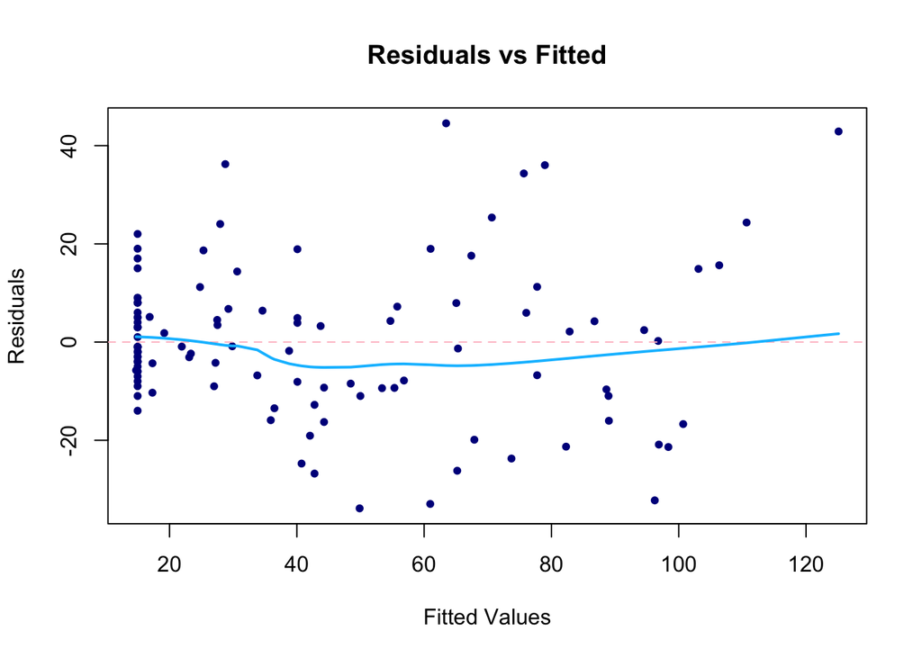

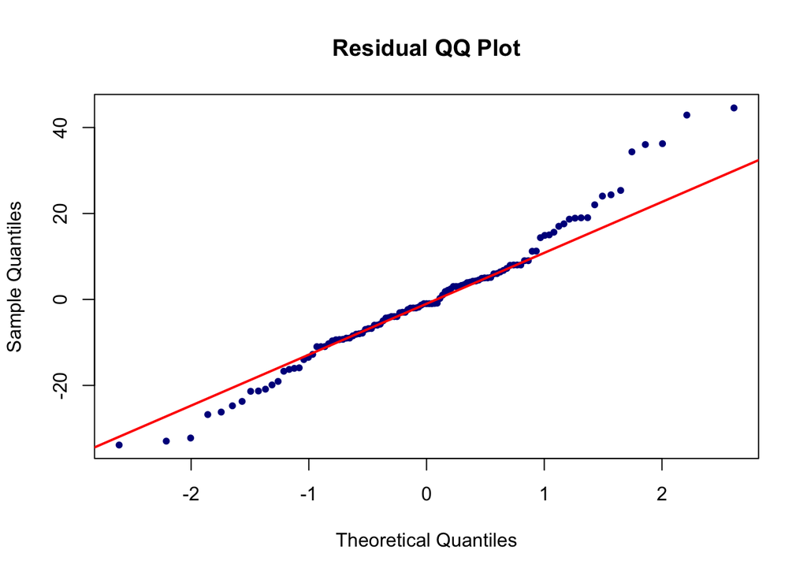

```r
plot.mars(fit_airquality)
```

```r
print.mars(fit_airquality)
```

```
## FUNCTION CALL:
##  mars(formula = Ozone ~ Solar.R + Wind + Temp, data = airquality_clean,
##     control = mc_airquality)
## RESULT:
##  Coefficients:
##  14.9833205769473    B0
##  4.18452985864054    B2
##  16.34993425529  B3
##  -1.15261393676273   B6
##  -0.0210145819702353 B7
```

## test3 dataset of gapminder

```r
#test3
# Load the gapminder dataset
if (!requireNamespace("gapminder", quietly = TRUE)) {
  install.packages("gapminder")
}
library(gapminder)
data("gapminder")

gapminder_2007 <- subset(gapminder, year == 2007)

# Setting control parameters for the MARS model
mc_gapminder <- mars.control(Mmax=10)

# Fitting the MARS model to predict life expectancy based on GDP per capita and population
fit_gapminder <- mars(lifeExp ~ gdpPercap + pop, data=gapminder_2007, control=mc_gapminder)

# Making predictions with the fitted model
predict_gapminder <- predict(fit_gapminder)

# Displaying predictions
predict_gapminder
```

```
##   [1] 51.99062 68.35735 70.42392 69.97619 72.48216 79.28099 79.81191 77.82449
##   [9] 55.53189 79.04780 55.95710 69.67006 70.80786 72.41638 71.31629 71.82331
##  [17] 54.05120 47.36289 58.27300 61.06333 79.87242 49.70813 58.19043 72.60531
##  [25] 70.02701 70.66981 59.51433 46.06665 66.31858 71.49815 56.83644 73.05977
##  [33] 71.27934 75.63856 79.54566 51.14368 70.36176 70.62795 70.22231 70.26851
##  [41] 72.28585 49.15870 49.57885 78.89537 78.03608 72.61625 58.00872 78.56990
##  [49] 54.99098 77.11571 70.09826 51.71929 59.33565 53.92036 69.58410 80.94164
##  [57] 74.12396 79.82896 64.54886 69.58169 72.11369 69.87379 81.24021 76.48306
##  [65] 77.43948 70.76848 78.40843 69.88898 56.14377 57.24707 75.80019 83.32199
##  [73] 71.75433 56.01560 51.71558 72.25553 52.58716 50.16140 72.37927 52.56856
##  [81] 57.69379 71.91003 72.23043 60.07687 71.37534 69.66945 50.70818 51.73072
##  [89] 56.00783 52.98312 80.02271 76.37687 67.07397 48.97433 60.82436 83.96564
##  [97] 75.47621 65.85545 71.54968 69.78016 70.79612 69.47176 73.30173 74.90905
## [105] 74.53830 70.87812 71.86340 51.04306 54.86156 75.26858 58.26189 71.54256
## [113] 51.03841 83.27056 74.33411 76.55997 51.57894 71.38029 77.51839 69.71651
## [121] 65.82526 47.32559 79.10027 80.24513 69.78384 77.48612 53.12014 70.81165
## [129] 51.21204 74.12383 70.69691 71.12556 52.68583 78.89417 81.95465 71.80155
## [137] 72.05407 64.45848 68.59793 63.09180 54.51166 47.69977
```

```r
# Summarizing the fitted model
summary.mars(fit_gapminder)
```

```
## Summary of MARS Model
##
## Formula:
## lifeExp ~ gdpPercap + pop
##
## Number of Terms:  5
## Coefficients:
##            B0            B1            B2            B5            B7
##  6.941991e+01 -8.498903e-03  3.139468e-04  7.230273e-09 -2.678085e-09
##
## Goodness-of-Fit Measures:
## R-Squared:  0.7129
## Adjusted R-Squared:  0.7024
##
## Residual Statistics:
## Residual Mean:  0
## Residual Standard Deviation:  6.4687
```

```
## $formula
## lifeExp ~ gdpPercap + pop
##
## $n_terms
## [1] 5
##
## $coefficients
##            B0            B1            B2            B5            B7
##  6.941991e+01 -8.498903e-03  3.139468e-04  7.230273e-09 -2.678085e-09
##
## $r_squared
## [1] 0.7129181
##
## $adj_r_squared
## [1] 0.7023636
##
## $residual_mean
## [1] -5.751555e-16
##
## $residual_sd
## [1] 6.468727
```

```r
# Analyzing the model's components with ANOVA
anova.mars(fit_gapminder)
```

```
## Intercept:
## * Variance explained by term: 0
## * Residual variance for term: 41.8444
## * Fitted value variance for term: 103.9134
##
## Term: B1
## * Variance explained by term: 58.9476
## * Residual variance for term: 53748278.3776
## * Fitted value variance for term: 2241469324.416
##
## Term: B2
## * Variance explained by term: 15.1265
## * Residual variance for term: 2731496938.8973
## * Fitted value variance for term: 991013933814.207
##
## Term: B5
## * Variance explained by term: 114.511
## * Residual variance for term: 1.801732564832e+20
## * Fitted value variance for term: 7.15896478863393e+21
##
## Term: B7
## * Variance explained by term: 107.8567
## * Residual variance for term: 1.18624216543091e+21
## * Fitted value variance for term: 4.75733039074909e+22
```

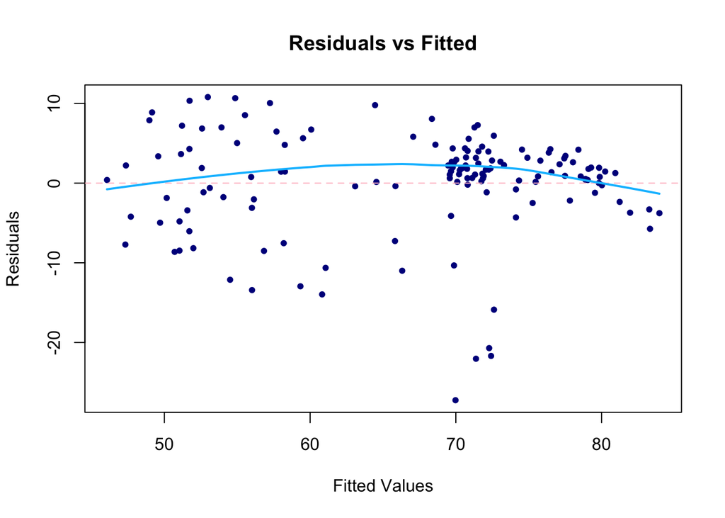

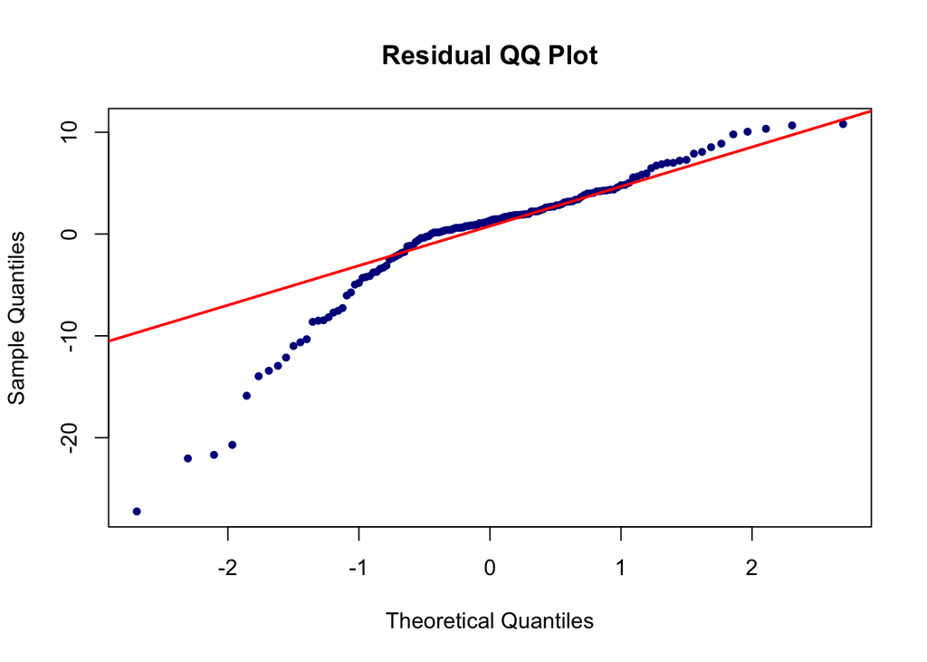

```r
# Plotting the MARS model
plot.mars(fit_gapminder)
```

```r
# Printing the model's details
print.mars(fit_gapminder)
```

```
## FUNCTION CALL:
##  mars(formula = lifeExp ~ gdpPercap + pop, data = gapminder_2007,
##     control = mc_gapminder)
## RESULT:
##  Coefficients:
##  69.4199126143884    B0
##  -0.00849890254455228    B1
##  0.000313946763854587    B2
##  7.23027276422736e-09    B5
##  -2.67808519953916e-09   B7
```